# problem-1

## **Formal Proof**

### **Question 1**

Let $n\in \mathbb{N}$, and $P$ be a path of order $n$. Prove that $P$ is bipartite.

#### Direct Proof

Let $P$ be a path of order $n$ with vertex set $V_n = \{v_i: 0 \leq i \leq n-1\}$. Note that for each $v_i \in V_n$, we have $v_i$ is only connected by an edge to $v_{i-1}$ and $v_{i+1}$ (if they exist).

We may partition $V_n$ into the sets:

- $A = \{v_i \in V : i \text{ is odd}\}$
- $B = \{v_i \in V : i \text{ is even}\}$

If the number $i$ is **even**, then $v_{i-1}$ and $v_{i+1}$ are in subset A;  
If the number $i$ is **odd**, then $v_{i-1}$ and $v_{i+1}$ are in subset B.

It follows that for each $v_i \in V$:

- If $i$ is **odd**, then $v_i \in A$ and is only connected to vertices in $B$.
- If $i$ is **even**, then $v_i \in B$ and is only connected to vertices in $A$.

Therefore, $A, B$ partitions $V_n$ into independent sets, showing that $P$ is bipartite.

#### Proof by Induction

We proceed by induction. We first consider the base case: $n = 0$. In this case, $P$ is the empty graph with no vertices or edges. It follows that $P$ is bipartite: its vertex set is $\emptyset$, which is partitioned into $\emptyset \cup \emptyset$. Since $\emptyset$ has no vertices, it is trivially independent.

Now we proceed to the inductive step. Assume that for $n \in \mathbb{N}$, the path $P_n$ of order $n$ is bipartite. We need to show that the path $P_{n+1}$ of order $n+1$ is also bipartite.

Let $P_{n+1}$ have the vertex set:

$$ V_{n+1} = \{v_i: 0 \leq i \leq n\} $$

Note that $P_n$ embeds in $P_{n+1}$ by considering the subgraph with vertices:

$$ V_n = \{v_i: 0 \leq i \leq n-1\} $$

Thus, there exists a partition $A \cup B$ of $V_n$ such that the vertices in $A$ are independent and the vertices in $B$ are independent in $P_n$.

##### Case: $n = 0$

If $n = 0$, then $V_0 = \emptyset$ must be partitioned into $A = \emptyset, B = \emptyset$.  
So for $V_{n+1} = V_1 = \{v_0\}$, we may choose:

- $A' = \{v_0\}$,
- $B' = \emptyset$

This is a partition of $V_{n+1}$ into independent sets.

##### Case: $n > 0$

If $n > 0$, then $V_n$ must be partitioned into some $A, B$. So for:

$$ V_{n+1} = \{v_i: 0 \leq i \leq n\} = \{v_i: 0 \leq i \leq n-1\} \cup \{v_n\} = V_n \cup \{v_n\} $$

We consider $v_{n-1} \in V_n$ (which exists as $n > 0$). Without loss of generality, assume $v_{n-1} \in A$. It follows that we may partition $V_{n+1}$ into:

- $A' = A$
- $B' = B \cup \{v_n\}$

Since $A' = A$, it remains independent.  
Since $B' = B \cup \{v_n\}$ and $B$ is independent, we need only show that $v_n$ isn't connected by an edge to any vertex in $B$.

Since $v_n$ is only connected by an edge to $v_{n-1}$ and $v_{n-1} \not\in B$, $v_n$ cannot be connected to a vertex in $B$, showing that $B'$ is independent.

Thus, by induction, $P$ is bipartite.

## **Code Demonstration**

```
Graph G (order 5) is bipartite.
Bipartition of vertices:
Set A (even-indexed vertices): {0, 2, 4}
Set B (odd-indexed vertices): {1, 3}
```

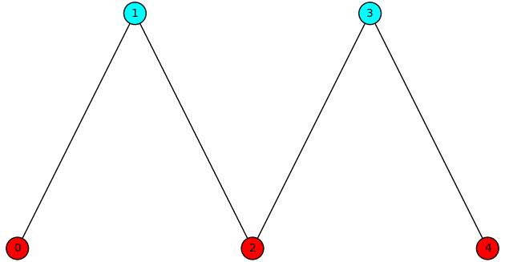

```
Graph G (order 10) is bipartite.
Bipartition of vertices:
Set A (even-indexed vertices): {0, 2, 4, 6, 8}
Set B (odd-indexed vertices): {1, 3, 5, 7, 9}
```

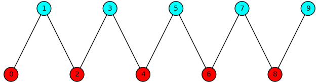

```
Graph G (order 15) is bipartite.
Bipartition of vertices:
Set A (even-indexed vertices): {0, 2, 4, 6, 8, 10, 12, 14}
Set B (odd-indexed vertices): {1, 3, 5, 7, 9, 11, 13}
```

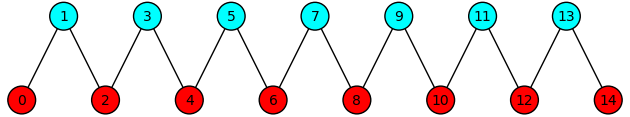

```
Graph G (order 20) is bipartite.
Bipartition of vertices:
Set A (even-indexed vertices): {0, 2, 4, 6, 8, 10, 12, 14, 16, 18}
Set B (odd-indexed vertices): {1, 3, 5, 7, 9, 11, 13, 15, 17, 19}
```

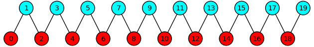

```python
for n in range(5,21,5):
    G = graphs.PathGraph(n)

    if G.is_bipartite():
        print(f"Graph G (order {n}) is bipartite.")

        # Obtain and print the bipartition of the graph
        bipartition = G.bipartite_sets()
        print("Bipartition of vertices:")
        print("Set A (even-indexed vertices):", bipartition[0])
        print("Set B (odd-indexed vertices):", bipartition[1])

        # Reshape the graph into a "W" shape
        vertex_positions = {v: (v, 1 if v % 2 == 1 else -1) for v in G.vertices()}

        # Show the graph, with color-coded vertices for sets "A" and "B"
        v_order = list(G.vertices())
        vcolors = ["red" if v % 2 == 0 else "aqua" for v in v_order]
        G.plot(vertex_labels=True, vertex_size=400, vertex_colors=vcolors, pos=vertex_positions).show()
    else:
        print(f"Graph G (order {n}) is not bipartite.")
```